# 07_08_2020

## The Daily Graph

### Introduction and summary.

#### The spikes continue. Campbell county had a noticable rise in cases yesterday, registering the most cases ever reported for a single day (23).

```
          07/07/2020
```

### Summary for selected counties

| Statistic | Campbell, KY | Fulton, GA | Hamilton, OH | Leon, FL |
| --- | --- | --- | --- | --- |
| Population | 93,584 | 1,063,937 | 817,473 | 293,582 |
| Cases | 293 | 8,883 | 6,019 | 1,870 |
| Deaths | 13 | 316 | 198 | 8 |
| Cases per 100,000 | 313 | 834 | 736 | 636 |
| Deaths per 100,000 | 13 | 29 | 24 | 2 |
| Date of first case | 3/24/20 | 3/3/20 | 3/19/20 | 3/19/20 |
| Number of Days | 105 | 126 | 110 | 110 |
| Maximum Number of Cases | 23 | 520 | 381 | 228 |

## The last 7 days

The following table displays the number of new cases for the lastest 7 days of available data in each of the counties. The zero probably means a missing day's data since I calculate new cases based on the cumulative number.

| Date | Campbell | Fulton | Hamilton | Leon |
| --- | --- | --- | --- | --- |
| 6/30/20 | 7 | 317 | 88 | 116 |
| 7/1/20 | 6 | 312 | 214 | 35 |
| 7/2/20 | 5 | 250 | 0 | 228 |
| 7/3/20 | 3 | 386 | 381 | 89 |
| 7/4/20 | 0 | 520 | 165 | 172 |
| 7/5/20 | 0 | 219 | 154 | 160 |
| 7/6/20 | 23 | 231 | 95 | 72 |

## Examine new cases, moving averages

The moving averages have now been normalized as the number of cases per 100,000 population. As noted before, the averages are 'trailing' in that the point on the graph represents the average number of new confirmed cases for that day and the $k-1$ previous days ($k = 5,7,10$).

### A comparison of moving averages amongst the counties.

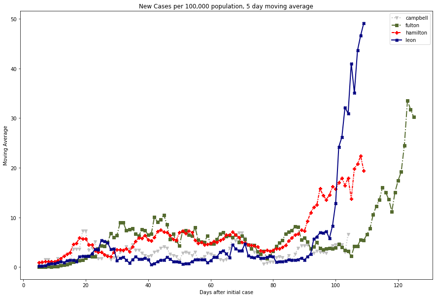

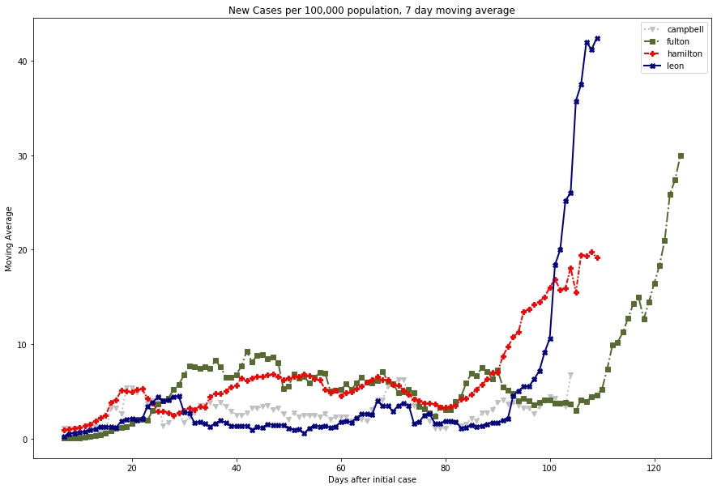

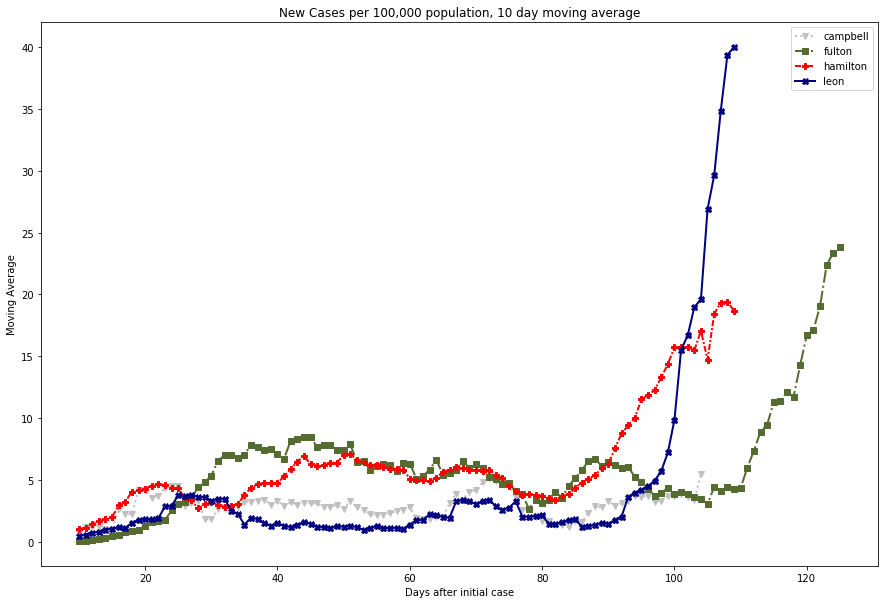

### A comparison of the different moving averages within counties.

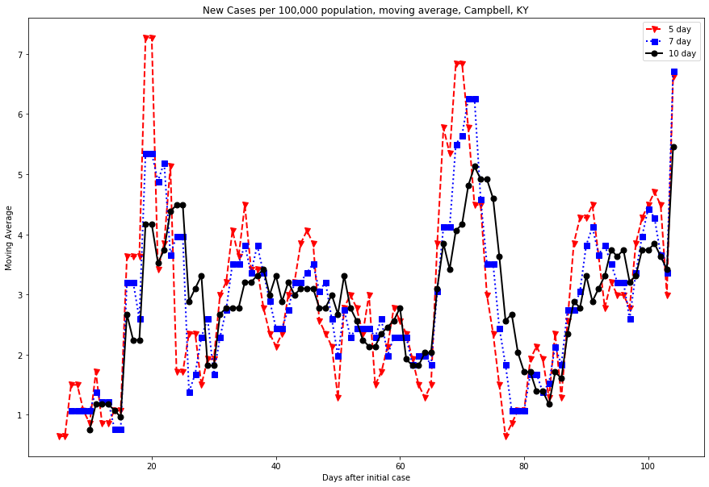

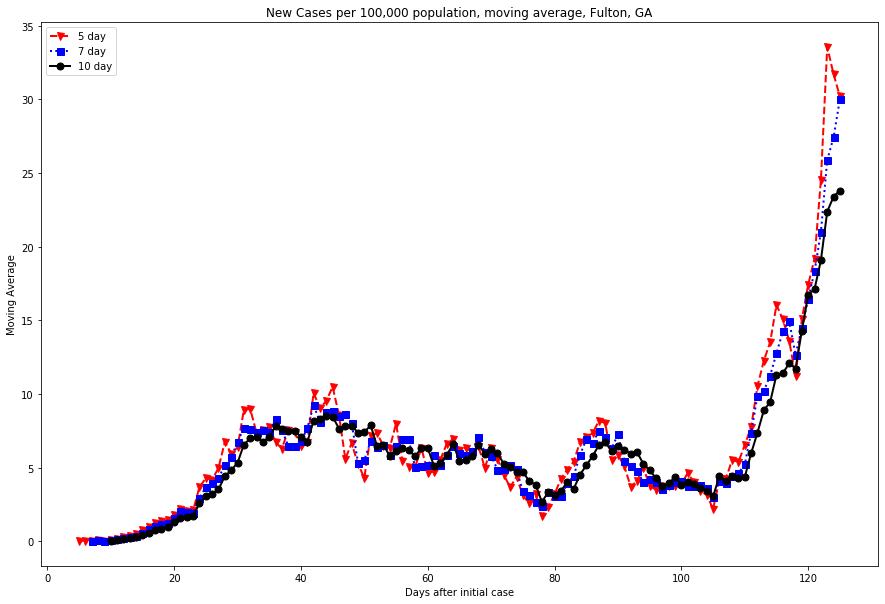

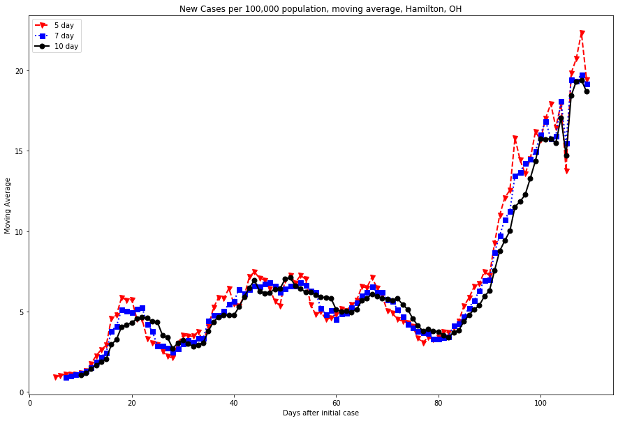

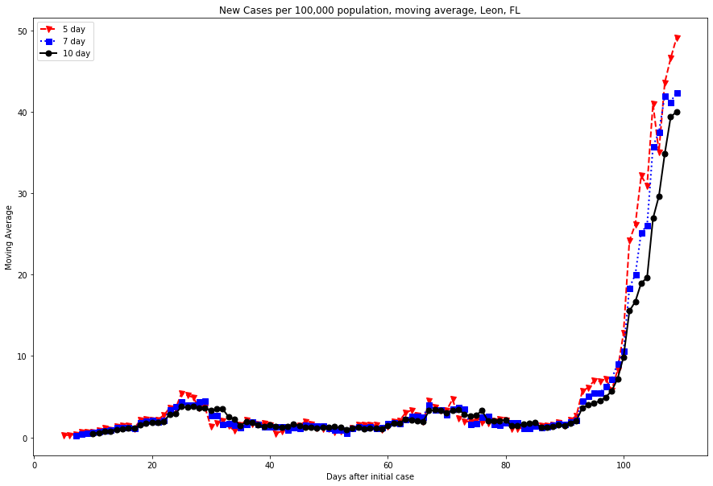

## Cumulative Number of cases by county.

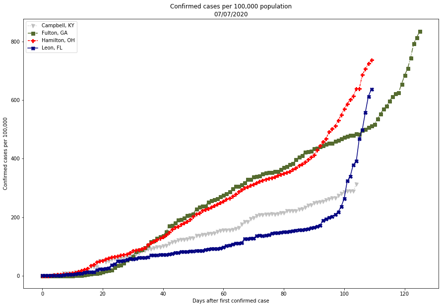

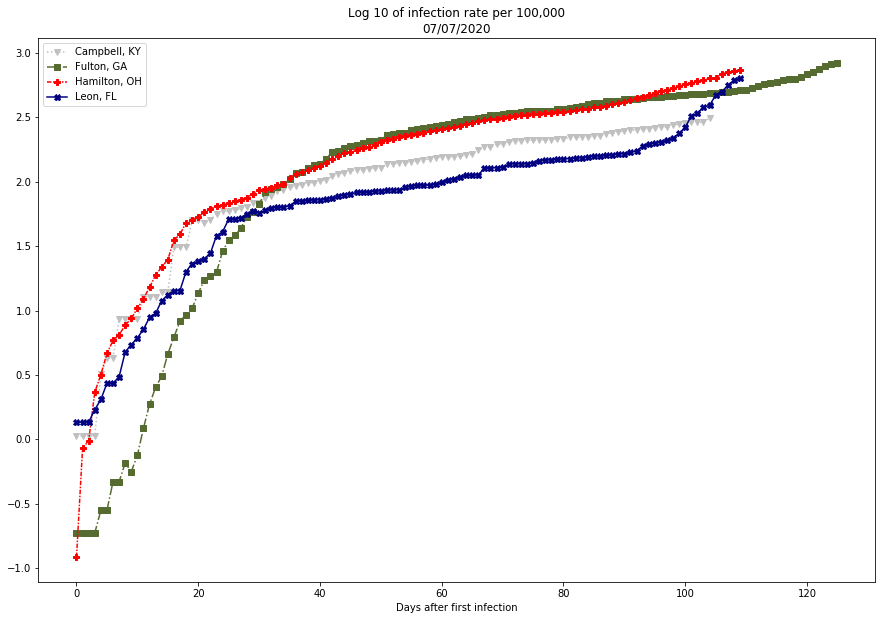